# Analysis of Daily Steps Taken

S Canata

2024-02-20

## Introduction

This study analizes the daily steps taken by an individual via a mobile device. The analisis consist of assessments of the mean total number of steps, the daily activity pattern, both without missing data and filling the “NA” entries with statistical data, and finally identifying the existance of different patterns during weekdays and weekend.

## Libraries

I’ve used the readr, dplyr, ggplot2 and lubridate libraries for this study, if you don’t have them installed please do so before running the code.

```r
library(readr)
library(dplyr)
```

```r
library(ggplot2)
library(lubridate)
```

## Loading data and processing

The dataset to be ised can be find in the same direction as a .csv file named “activisy.csv” inside a .zip file named “activity.zip”. The first step is to upload this data and read it.

```r
# Specify the path to the zip file
zip_file <- "activity.zip"

# Specify the file within the zip archive
csv_file_inside_zip <- "activity.csv"

# Unzip and read the CSV file
# This assumes the CSV file is directly inside the zip without any subfolders
unzipped_csv_path <- unzip(zip_file, files = csv_file_inside_zip, exdir = tempdir())

# Now read the CSV file into R
activity_data <- read_csv(file.path(tempdir(), csv_file_inside_zip))
```

## Mean Total Number of Steps Taken Per Day

### /This section was performed ignoring the missing values./

In this section we are calculating the total steps per day, building and printing an histogram of this data and printing the mean and median steps per day.

```r
library(dplyr)
library(ggplot2)

#Calculate the Total Number of Steps Taken Per Day
daily_steps <- activity_data %>%
  group_by(date) %>%
  summarise(total_steps = sum(steps))

#Setting a dataset that ignores NAs
daily_steps_no_na <- daily_steps[!is.na(daily_steps$total_steps), ]

print(daily_steps_no_na)
```

```
## # A tibble: 53 × 2
##    date       total_steps
##    <date>           <dbl>
##  1 2012-10-02         126
##  2 2012-10-03       11352
##  3 2012-10-04       12116
##  4 2012-10-05       13294
##  5 2012-10-06       15420
##  6 2012-10-07       11015
##  7 2012-10-09       12811
##  8 2012-10-10        9900
##  9 2012-10-11       10304
## 10 2012-10-12       17382
## # ℹ 43 more rows
```

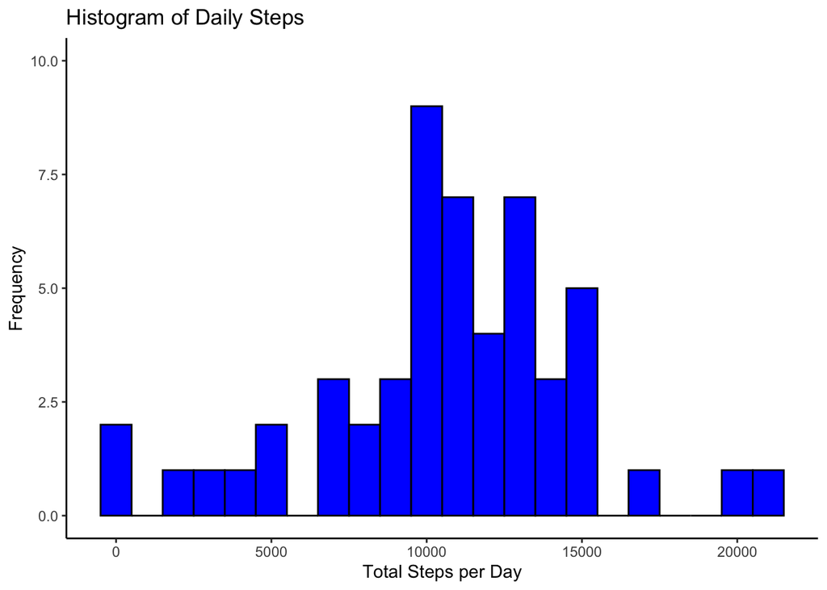

```r
#Build the histogram
ggplot(daily_steps_no_na, aes(x = total_steps)) +
  geom_histogram(binwidth = 1000, fill = "blue", color = "black") +
  theme_classic() +
  labs(title = "Histogram of Daily Steps", x = "Total Steps per Day", y = "Frequency") +
  ylim(0, 10)  # This will limit the y-axis but also might cut off bars taller than 10
```

```r
# Calculate and report mean and median
mean_daily_steps <- mean(daily_steps_no_na$total_steps)
median_daily_steps <- median(daily_steps_no_na$total_steps)

# Print the mean and median

print(paste("Mean of daily steps:", round(mean_daily_steps, 3)))
```

```
## [1] "Mean of daily steps: 10766.189"
```

```r
print(paste("Median of daily steps:", median_daily_steps))
```

```
## [1] "Median of daily steps: 10765"
```

We can see that the mean of daily steps is 10,766.189 and the median is 10,765.

## Average daily activity pattern

### /For this section we will continue ignoring the NA values of the dataset/

Now we proceed by Calculating the average number of steps per interval and build the time series. We also dettermine and print the maximum interval.

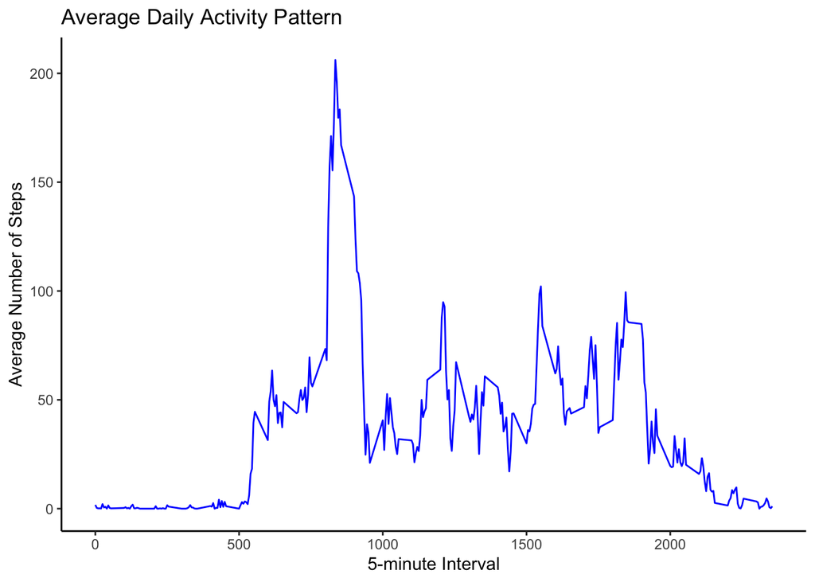

```r
# Calculate the average number of steps per interval
average_interval_steps <- activity_data %>%
  group_by(interval) %>%
  summarise(average_steps = mean(steps, na.rm = TRUE))

# Create the plot
average_daily_activity_plot <- ggplot(average_interval_steps, aes(x = interval, y = average_steps)) +
  geom_line(color = "blue") +
  theme_classic() +
  labs(title = "Average Daily Activity Pattern",
       x = "5-minute Interval",
       y = "Average Number of Steps")

# Display the plot
print(average_daily_activity_plot)
```

```r
# Identify the interval with the maximum average steps
max_interval <- average_interval_steps[which.max(average_interval_steps$average_steps), ]
print(max_interval)
```

```
## # A tibble: 1 × 2
##   interval average_steps
##      <dbl>         <dbl>
## 1      835          206.
```

## Adjusting the NA values

For this section, first we calculate the total ammount of missing values

```r
# Calculate total number of missing values
missing_values <- sum(is.na(activity_data$steps))
print(missing_values)
```

```
## [1] 2304
```

With this we know that there are 2304 missing values.

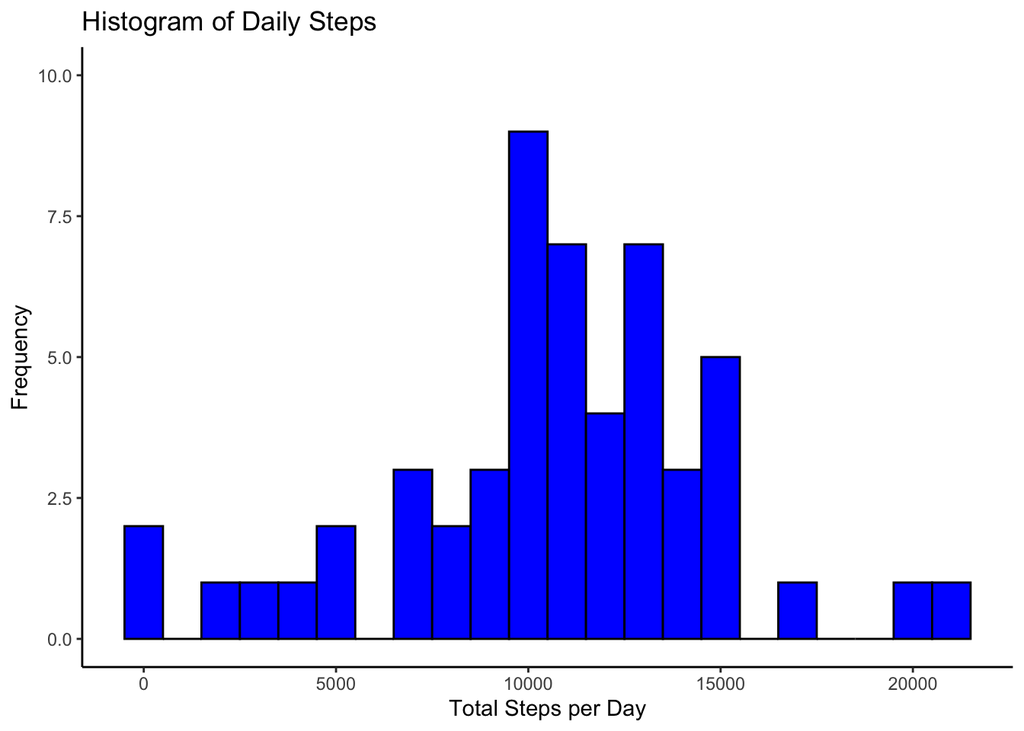

```r
activity_data$steps[is.na(activity_data$steps)] <- average_interval_steps$average_steps[match(activity_data$interval[is.na(activity_data$steps)], average_interval_steps$interval)]

ggplot(daily_steps, aes(x = total_steps)) +
  geom_histogram(binwidth = 1000, fill = "blue", color = "black") +
  theme_classic() +
  labs(title = "Histogram of Daily Steps", x = "Total Steps per Day", y = "Frequency") +
  ylim(0, 10)  # This will limit the y-axis but also might cut off bars taller than 10
```

```r
# Calculate and report mean and median
new_mean_daily_steps <- mean(daily_steps$total_steps)
new_median_daily_steps <- median(daily_steps$total_steps)

# Print the mean and median

print(paste("Mean of daily steps:", round(mean_daily_steps, 3)))
```

```
## [1] "Mean of daily steps: 10766.189"
```

```r
print(paste("Median of daily steps:", median_daily_steps))
```

```
## [1] "Median of daily steps: 10765"
```

Enable Complete Data Analysis: We are able to utilize the whole dataset, instead of compromising information.

Reduces Bias: I case the data is missing not at random, the exclution of it can provoke bias in the dataset.

Increases Statistical Power: By maximizing the sample size, which can increase the confidence in analysis.

## Differences in Activity Patterns Between Weekdays and Weekends

### /For this part we will use again the filled dataset from the previous section/

Now we want to identify significant differences between the weekdays and weekends data.

For this we first add a variable “day_type” to differentiate both categories

```r
# Create a new column 'day_type'
activity_data <- activity_data %>%
  mutate(day_of_week = weekdays(date),
         day_type = ifelse(day_of_week %in% c("Saturday", "Sunday"), "weekend", "weekday")) %>%
  mutate(day_type = as.factor(day_type))

#Calculate the Average Number of Steps for Each Interval by Day Type
average_steps_by_day_type <- activity_data %>%
  group_by(interval, day_type) %>%
  summarise(average_steps = mean(steps, na.rm = TRUE))
```

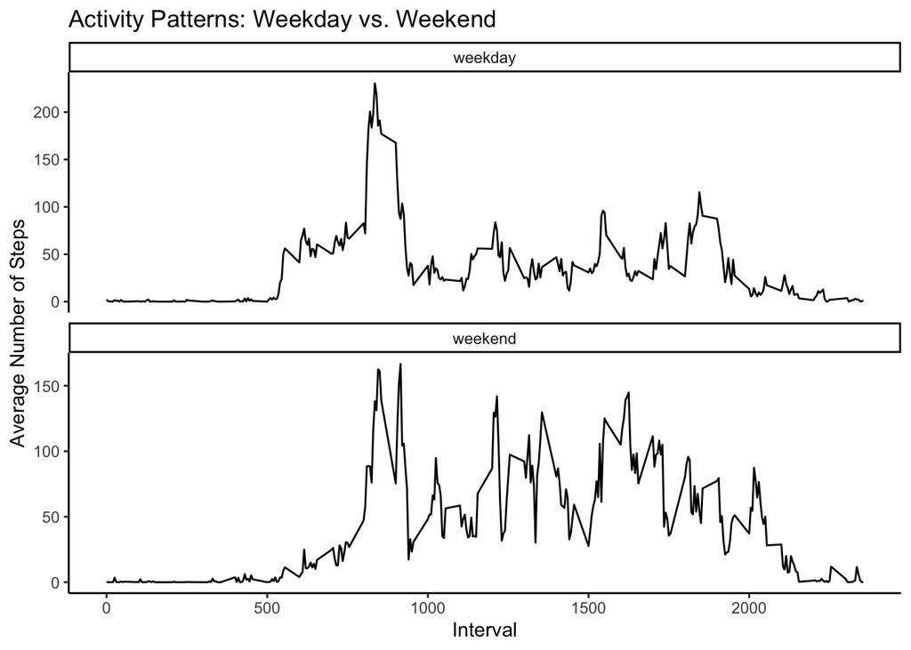

```r
#Create a Panel Plot
p <- ggplot(average_steps_by_day_type, aes(x = interval, y = average_steps)) +
  geom_line() +
  facet_wrap(~day_type, ncol = 1, scales = "free_y") +
  theme_classic() +
  labs(title = "Activity Patterns: Weekday vs. Weekend",
       x = "Interval",
       y = "Average Number of Steps")

print(p)
```

As we can see, the week days present a higher peak at the beggining of the day, but lower movement later on. This suggests that the subject walks more at a certain time of the day during weekdays, but during weekends they have more movement along the day.